# בוחן קורס מעבדה — סמסטר ב׳ תשפ״ד

21.7.2024

**הנחיות:**

- משך הבוחן — שעה
- בבוחן 2 שאלות (סה״כ 6 סעיפים). הניקוד לכל סעיף מופיע עליו.
- בבקשה לענות תשובות על גבי הטופס. אם חסר מקום, ניתן לענות בצד השני של הדף.

אני מבטיח לשמור על מהימנות הבוחן.

מספר ת״ז: _______________________

## שאלה 1

מוצגים שני גרפים של אומדי מספר עותקים. בציר ה-x: מיקום בכרומוזום. בציר ה-y: מספר עותקים ביחס למצב הבריא.

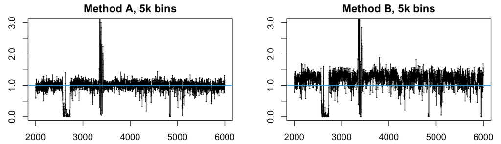

א. [20 נק׳]

בגרפים אלו קיים קו מחבר בין כל שתי נקודות עוקבות. רשמו יתרון אחד וחסרון אחד של הוספת הקווים המחברים על פני גרף נקודות בלבד.

ב. [20 נק׳]

(סעיפים ב׳ וג׳ — אנא הסבירו במילים. ניתן גם להראות על גבי הגרפים.)  
הציעו תוספת לגרף שתאפשר להשוות באופן ויזואלי את הפיזור של שני התיקונים.

ג. [10 נק׳]

הציעו שיפור אחד נוסף לגרפים.

## שאלה 2

לצורך אמידת הקשר בין GC לבין כיסוי (מספר פרגמנטים בתא), יובל אומד קו מגמה בעזרת רגרסיית spline מדרגה 1 עם knot בודד ב-GC = 0.57.  
בגרף רואים את השאריות R כנגד GC. עליו יובל שרטט בקירוב את קו המגמה, כלומר את 𝐸[𝑅|𝐺𝐶].

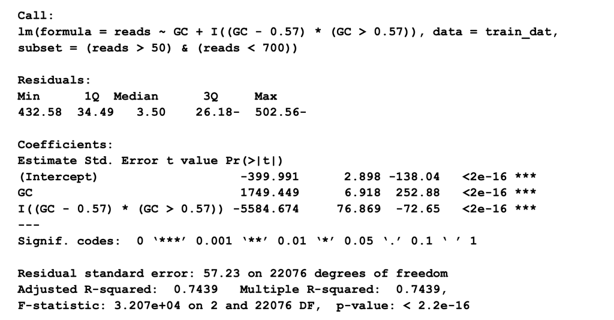

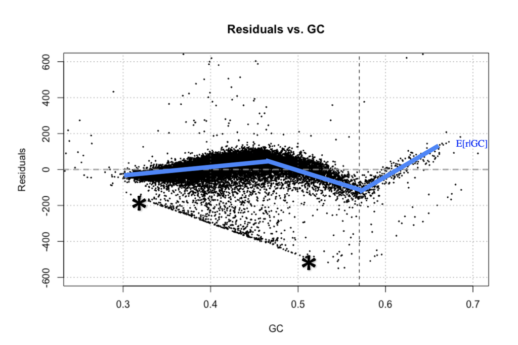

א. [20 נק׳]

עבור ערכי GC > 0.6, בכמה עולה התחזית של הכיסוי 𝑓̂(𝐺𝐶) עבור כל תוספת של 1% (0.01) ב-GC?

ב. [15 נק׳]

לפי גרף השאריות, לאילו מהפונקציות נראה שיש שיפוע גבוה יותר עבור ערכי GC > 0.6?

א. התחזית 𝑓̂(𝐺𝐶)

ב. הנצצות 𝑓(𝐺𝐶)

ג. לא ניתן לדעת

**הסבר:**

ג. [15 נק׳]

בתחתית גרף השאריות ניתן לראות נקודות מסודרות באלכסון (מסומן ב-*). הסבירו מהן נקודות אלו.